# hw2_5

```python
#Part a) EDA
# i)
import pandas as pd
import numpy as np
import matplotlib.pyplot as plt
import seaborn as sns

data_path="pulsar_data_train.csv"
df = pd.read_csv(data_path)

print (f"Shape: {df.shape}")
print (f"Data types:\n{df.dtypes}")
print ("\n ================= Describe =================\n")
print(df.describe())

pulsar_percent = (df['target_class'].sum() / len(df)) * 100  #since target is 0,1 we can simply sum all rows
print (f"\n\nPercentage of pulsars: {pulsar_percent:.2f}%")
```

```
Shape: (12528, 9)
Data types:
 Mean of the integrated profile                  float64
 Standard deviation of the integrated profile    float64
 Excess kurtosis of the integrated profile       float64
 Skewness of the integrated profile              float64
 Mean of the DM-SNR curve                        float64
 Standard deviation of the DM-SNR curve          float64
 Excess kurtosis of the DM-SNR curve             float64
 Skewness of the DM-SNR curve                    float64
target_class                                     float64
dtype: object

 ================= Describe =================

        Mean of the integrated profile  \
count                     12528.000000
mean                        111.041841
std                          25.672828
min                           5.812500
25%                         100.871094
50%                         115.183594
75%                         127.109375
max                         189.734375

        Standard deviation of the integrated profile  \
count                                   12528.000000
mean                                       46.521437
std                                         6.801077
min                                        24.772042
25%                                        42.362222
50%                                        46.931022
75%                                        50.979103
max                                        91.808628

        Excess kurtosis of the integrated profile  \
count                                10793.000000
mean                                     0.478548
std                                      1.064708
min                                     -1.738021
```

[output cut: 32 more lines]

```
75%                               10.727927                     139.997850
max                               34.539844                    1191.000837

       target_class
count  12528.000000
mean       0.092034
std        0.289085
min        0.000000
25%        0.000000
50%        0.000000
75%        0.000000
max        1.000000


Percentage of pulsars: 9.20%
```

Accuracy alone can be misleading because the percentage of pulsars is very low. A simple model guessing every datapoint is 0 will be correct 90.8% of times.

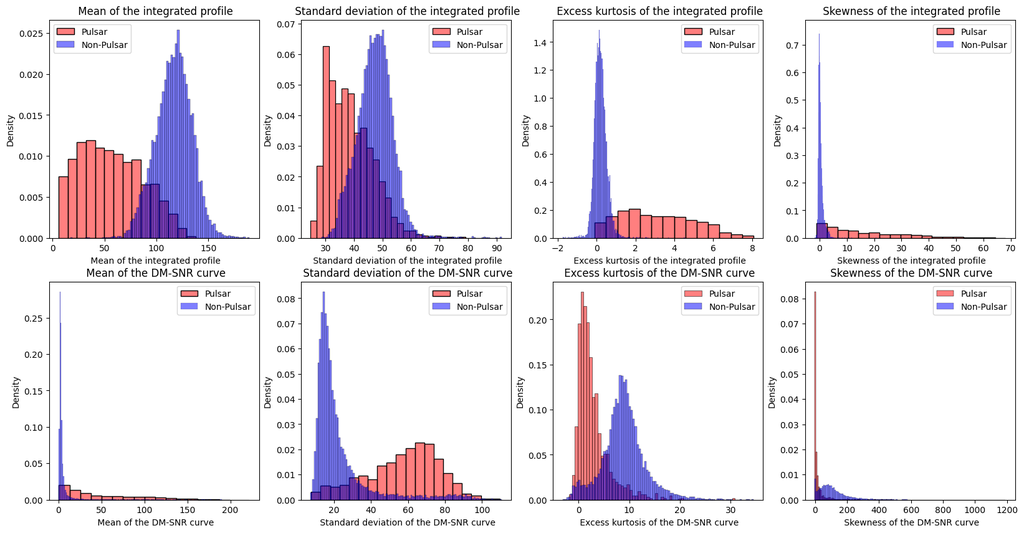

```python
# ii)
fig, axes = plt.subplots(2, 4, figsize=(20, 10))
axes = axes.flatten()
features = df.columns[:-1].tolist()
target = df.columns[-1]

for i, col in enumerate(features):
    # Filter using the target name we just grabbed
    pulsars = df[df[target] == 1][col]
    non_pulsars = df[df[target] == 0][col]

    sns.histplot(pulsars, color='red', label='Pulsar',
                 alpha=0.5, ax=axes[i], kde=False, stat="density")
    sns.histplot(non_pulsars, color='blue', label='Non-Pulsar',
                 alpha=0.5, ax=axes[i], kde=False, stat="density")

    axes[i].set_title(col)
    axes[i].legend()
```

The most important features look like Excess Kurtosis of the DM-SNR curve, Standard deviation of DM-SNR curve, and skewness of the integrated profile

```python
#iii)
import numpy as np
from sklearn.model_selection import train_test_split

df_clean = df.dropna()
X = df_clean.iloc[:, :-1].values
y = df_clean.iloc[:, -1].values

y = np.where(y == 0, -1, 1)

X_train, X_temp, y_train, y_temp = train_test_split(
    X, y, test_size=0.40, random_state=42, stratify=y
)
X_val, X_test, y_val, y_test = train_test_split(
    X_temp, y_temp, test_size=0.50, random_state=42, stratify=y_temp
)

train_mean = np.mean(X_train, axis=0)
train_std = np.std(X_train, axis=0)

#If any standard deviation is 0, replace it with 1 to prevent division by zero
train_std = np.where(train_std == 0, 1.0, train_std)

X_train_scaled = (X_train - train_mean) / train_std
X_val_scaled = (X_val - train_mean) / train_std
X_test_scaled = (X_test - train_mean) / train_std

X_train_final = np.c_[X_train_scaled, np.ones(X_train_scaled.shape[0])]
X_val_final = np.c_[X_val_scaled, np.ones(X_val_scaled.shape[0])]
X_test_final = np.c_[X_test_scaled, np.ones(X_test_scaled.shape[0])]

y_train = y_train.flatten()
y_val = y_val.flatten()
y_test = y_test.flatten()

print(f"X_train shape: {X_train_final.shape} (Includes 8 features + 1 bias column)")
print(f"y_train shape: {y_train.shape}")
print(f"y_train unique labels: {np.unique(y_train)}")
print("2. X_train NaNs:", np.isnan(X_train_final).any())
```

```
X_train shape: (5563, 9) (Includes 8 features + 1 bias column)
y_train shape: (5563,)
y_train unique labels: [-1  1]
2. X_train NaNs: False
```

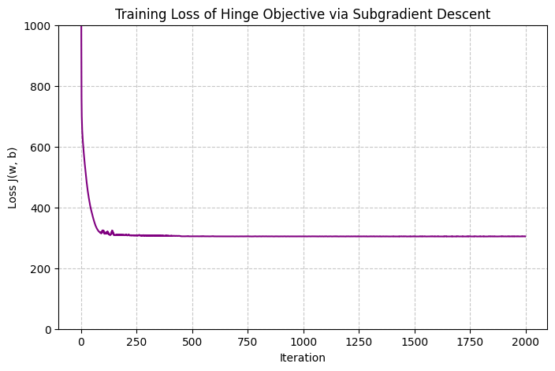

```python
# b)
# i)
def compute_gradient_hinge(X, y, w, lambda_reg):

    margins = y * np.dot(X, w)

    active_multipliers = -y * (margins < 1)
    grad_loss = np.dot(X.T, active_multipliers)

    w_reg = w.copy()
    w_reg[-1] = 0  #don't regularize the bias term

    grad_reg = lambda_reg * w_reg

    grad_total = grad_loss + grad_reg

    return grad_total

def compute_J_hinge(X, y, w, lambda_reg):
    # 1. Hinge loss: sum(max(0, 1 - m_n))
    margins = y * np.dot(X, w)
    hinge_loss = np.sum(np.maximum(0, 1 - margins))

    # 2. Regularization: (lambda / 2) * ||w||^2
    w_no_bias = w[:-1]
    reg_loss = (lambda_reg / 2) * np.sum(w_no_bias**2)

    return hinge_loss + reg_loss

lambda_reg = 1e-3
eta = 1e-3
iterations = 2000

def train_hinge_model(X_train, y_train, lambda_reg, eta, iterations):
    w = np.zeros(X_train.shape[1])
    loss_history = []

    # Training Loop
    for i in range(iterations):
        # Calculate and store current loss
        current_loss = compute_J_hinge(X_train, y_train, w, lambda_reg)
        loss_history.append(current_loss)

        # Compute gradient
        grad = compute_gradient_hinge(X_train_final, y_train, w, lambda_reg)

        # Update weights
        w = w - eta * grad

    return w, loss_history

w_hinge, loss_history = train_hinge_model(X_train_final, y_train, lambda_reg, eta, iterations)
# Plotting the loss
plt.figure(figsize=(8, 5))
plt.plot(range(iterations), loss_history, color='purple', linewidth=1.5)
plt.title('Training Loss of Hinge Objective via Subgradient Descent')
plt.ylim(0, 1000)
plt.xlabel('Iteration')
plt.ylabel('Loss J(w, b)')
plt.grid(True, linestyle='--', alpha=0.7)
plt.show()
```

The loss does not decrease monotonically because the loss function is not differentiable at 0, which causes the gradient to change abruptly.

```python
# iii)
def compute_accuracy(x,y,w):
    y_train_pred = np.sign(np.dot(X_train_final, w))
    y_val_pred = np.sign(np.dot(X_val_final, w))

    # Edge cases
    y_train_pred[y_train_pred == 0] = -1
    y_val_pred[y_val_pred == 0] = -1

    train_acc = np.mean(y_train_pred == y_train)
    val_acc = np.mean(y_val_pred == y_val)

    return train_acc, val_acc


train_acc_hinge, val_acc_hinge = compute_accuracy(X_train_final, y_train, w_hinge)
print(f"Training Accuracy:   {train_acc_hinge:.4f}")
print(f"Validation Accuracy: {val_acc_hinge:.4f}\n")

# Recalculate margins for the final weights
margins = y_train * np.dot(X_train_final, w_hinge)

# Create boolean masks for safe (m >= 1) and active (m < 1) points
zero_subgradient_mask = margins >= 1
active_mask = margins < 1

print("--- Active Mass (m < 1, Pulling Boundary) ---")
print(f"Total active points:     {np.sum(active_mask)}")
print(f"Active Pulsars (+1):     {np.sum(active_mask & (y_train == 1))}")
print(f"Active Non-Pulsars (-1): {np.sum(active_mask & (y_train == -1))}")
```

```
Training Accuracy:   0.9788
Validation Accuracy: 0.9811

--- Active Mass (m < 1, Pulling Boundary) ---
Total active points:     301
Active Pulsars (+1):     157
Active Non-Pulsars (-1): 144
```

The numbers are similar, but there is a slightly edge for the rare class to be more active (although much greater in percentage of active points). That matches my intution because its is harder to confidently identify a pulsar because of how rare they are (and overlap between features).

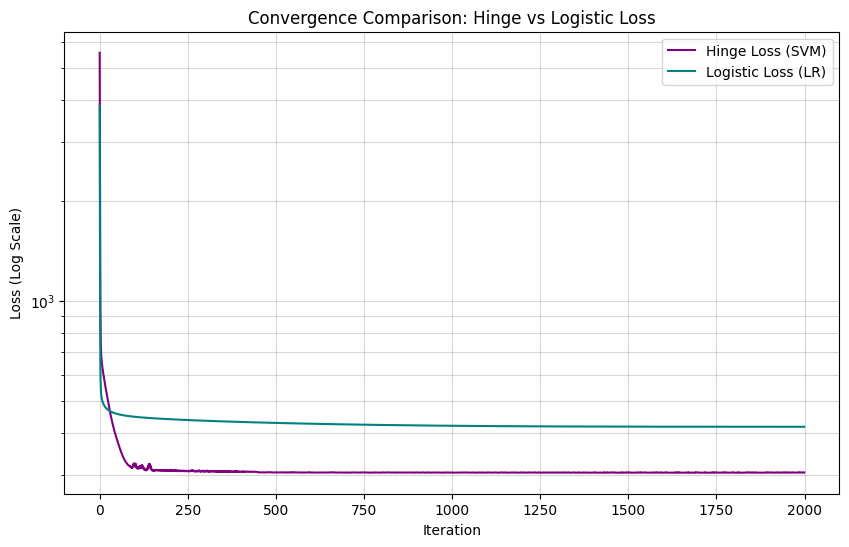

```python
# c)
# ii)

def compute_J_log(X, y, w, lambda_reg):
    margins = y * np.dot(X, w)

    loss_val = np.sum(np.logaddexp(0, -margins))

    reg_loss = (lambda_reg / 2) * np.sum(w[:-1]**2)

    return loss_val + reg_loss

def compute_gradient_log(X, y, w, lambda_reg):

    margins = y * np.dot(X, w)
    sigma_neg_m = 1 / (1 + np.exp(margins))

    active_multipliers = -y * sigma_neg_m
    grad_loss = np.dot(X.T, active_multipliers)

    w_reg = w.copy()
    w_reg[-1] = 0
    grad_reg = lambda_reg * w_reg

    return grad_loss + grad_reg

def train_log_model(X_train, y_train, lambda_reg, eta, iterations):
    # Initialize
    w_log = np.zeros(X_train_final.shape[1])
    log_loss_history = []

    # Training Loop for Logistic Loss
    for i in range(iterations):
        current_loss = compute_J_log(X_train_final, y_train, w_log, lambda_reg)
        log_loss_history.append(current_loss)

        grad = compute_gradient_log(X_train_final, y_train, w_log, lambda_reg)
        w_log = w_log - eta * grad

    return w_log, log_loss_history

w_log, log_loss_history = train_log_model(X_train_final, y_train, lambda_reg, eta, iterations)
# Plotting Comparison
plt.figure(figsize=(10, 6))
plt.plot(loss_history, label='Hinge Loss (SVM)', color='purple')
plt.plot(log_loss_history, label='Logistic Loss (LR)', color='teal')
plt.yscale('log')  # Log scale as requested
plt.title('Convergence Comparison: Hinge vs Logistic Loss')
plt.xlabel('Iteration')
plt.ylabel('Loss (Log Scale)')
plt.legend()
plt.grid(True, which="both", ls="-", alpha=0.5)
plt.show()
```

Hinge Loss converges faster. Although it is a bit more irregular, by iteration 500 there is basically no more changes to the final loss value, while logistic loss still has some ajustments

```python
# iii)
train_acc_log, val_acc_log = compute_accuracy(X_train_final, y_train, w_log)
print(f"Training Accuracy:   {train_acc_log:.4f}")
print(f"Validation Accuracy: {val_acc_log:.4f}\n")

margins_log = y_train * np.dot(X_train_final, w_log)
sigma_neg_m = 1 / (1 + np.exp(margins_log))
x_norms = np.linalg.norm(X_train_final, axis=1)

grad_norms = sigma_neg_m * x_norms

exactly_zero = np.sum(grad_norms == 0)
below_threshold = np.sum(grad_norms < 1e-6)

print(f"Examples with gradient exactly zero: {exactly_zero}")
print(f"Examples with gradient < 10^-6:      {below_threshold}")
```

```
Training Accuracy:   0.9790
Validation Accuracy: 0.9795

Examples with gradient exactly zero: 0
Examples with gradient < 10^-6:      13
```

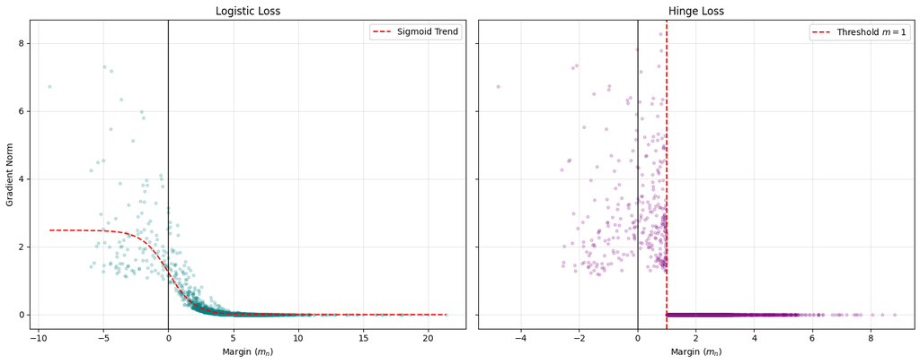

```python
# d)
# i)
margins_log = y_train * np.dot(X_train_final, w_log)
sigma_neg_m = 1 / (1 + np.exp(margins_log))
x_norms = np.linalg.norm(X_train_final, axis=1)
grad_norms = sigma_neg_m * x_norms

margins_hinge = y_train * np.dot(X_train_final, w_hinge)
grad_norms_hinge = np.where(margins_hinge < 1, np.linalg.norm(X_train_final, axis=1), 0)

# Create side-by-side subplots
fig, (ax1, ax2) = plt.subplots(1, 2, figsize=(15, 6), sharey=True)

# Logistic Subplot
ax1.scatter(margins_log, grad_norms, alpha=0.2, s=10, color='teal')
m_range_log = np.linspace(margins_log.min(), margins_log.max(), 100)
ax1.plot(m_range_log, (1/(1+np.exp(m_range_log))) * np.mean(x_norms), color='red', linestyle='--', label='Sigmoid Trend')
ax1.set_title('Logistic Loss')
ax1.set_xlabel('Margin ($m_n$)')
ax1.set_ylabel('Gradient Norm')
ax1.axvline(0, color='black', lw=1)
ax1.grid(alpha=0.3)
ax1.legend()

# Hinge Subplot
ax2.scatter(margins_hinge, grad_norms_hinge, alpha=0.2, s=10, color='purple')
ax2.set_title('Hinge Loss')
ax2.set_xlabel('Margin ($m_n$)')
ax2.axvline(1, color='red', linestyle='--', label='Threshold $m=1$')
ax2.axvline(0, color='black', lw=1)
ax2.grid(alpha=0.3)
ax2.legend()

plt.tight_layout()
plt.show()
```

Hinge loss totally "inactivates" a point after it becomes greater than the margin (mn>1). Those points stop mattering to the computation as their impact on the gradient becomes exactly zero. On the other hand, logistic uses exponentials to get a similar effect, but since there is no hard barrier (a continuous exponential instead) points start mattering less the further away from the margin they are, but never become a zero contribution to the gradient

```python
# e)
# i)
np.random.seed(0)
N_train = len(y_train)
num_to_flip = int(0.05 * N_train)

flip_indices = np.random.choice(N_train, size=num_to_flip, replace=False)
y_train_corrupted = y_train.copy()
y_train_corrupted[flip_indices] *= -1

# Verification
print(f"Total training examples: {N_train}")
print(f"Number of labels flipped: {num_to_flip}")
```

```
Total training examples: 5563
Number of labels flipped: 278
```

```python
w_hinge_corrupted, loss_history_corrupted = train_hinge_model(X_train_final, y_train_corrupted, lambda_reg, eta, iterations)
w_log_corrupted, log_loss_history_corrupted = train_log_model(X_train_final, y_train_corrupted, lambda_reg, eta, iterations)
train_acc_hinge_corrupted, val_acc_hinge_corrupted = compute_accuracy(X_train_final, y_train_corrupted, w_hinge_corrupted)
train_acc_log_corrupted, val_acc_log_corrupted = compute_accuracy(X_train_final, y_train_corrupted, w_log_corrupted)

print(f"---Hinge Loss---")
print(f"Original Training Accuracy:   {100*train_acc_hinge:.2f}%")
print(f"Original Validation Accuracy: {100*val_acc_hinge:.2f}%")
print(f"Corrupted Training Accuracy:   {100*train_acc_hinge_corrupted:.2f}%")
print(f"Corrupted Validation Accuracy: {100*val_acc_hinge_corrupted:.2f}%\n")

print(f"---Logistic Loss---")
print(f"Original Training Accuracy:   {100*train_acc_log:.2f}%")
print(f"Original Validation Accuracy: {100*val_acc_log:.2f}%")
print(f"Corrupted Training Accuracy:   {100*train_acc_log_corrupted:.2f}%")
print(f"Corrupted Validation Accuracy: {100*val_acc_log_corrupted:.2f}%\n")
```

```
---Hinge Loss---
Original Training Accuracy:   97.88%
Original Validation Accuracy: 98.11%
Corrupted Training Accuracy:   97.74%
Corrupted Validation Accuracy: 97.95%

---Logistic Loss---
Original Training Accuracy:   97.90%
Original Validation Accuracy: 97.95%
Corrupted Training Accuracy:   97.43%
Corrupted Validation Accuracy: 97.95%
```

The Hinge loss is more sensitive to noise. This matches our expectation because hinge loss has no limit in how much a wrong point drags the subgradient (it scales linearly with magnitude of x) unlike logistic loss, which limits the correction to magnitude of x

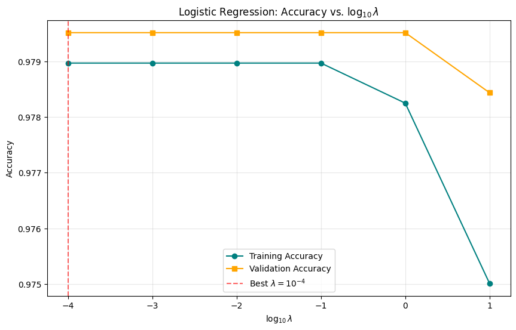

```
Optimal Lambda (λ*): 0.0001
Validation Accuracy at λ*: 0.9795
```

```python
# f)
# i) and ii)

lambdas=[1e-4, 1e-3, 1e-2, 1e-1,1,10]
train_acc_log_results = []
val_acc_log_results = []
for l in lambdas:
    w_log, log_loss_history = train_log_model(X_train_final, y_train, l, eta, iterations)
    train_acc_log, val_acc_log = compute_accuracy(X_train_final, y_train, w_log)
    train_acc_log_results.append(train_acc_log)
    val_acc_log_results.append(val_acc_log)

log_lambdas = np.log10(lambdas)

best_idx = np.argmax(val_acc_log_results)
lambda_star = lambdas[best_idx]

plt.figure(figsize=(10, 6))
plt.plot(log_lambdas, train_acc_log_results, marker='o', label='Training Accuracy', color='teal')
plt.plot(log_lambdas, val_acc_log_results, marker='s', label='Validation Accuracy', color='orange')

# Mark the optimal lambda
plt.axvline(log_lambdas[best_idx], color='red', linestyle='--', alpha=0.6,
            label=f'Best $\\lambda = 10^{{{int(log_lambdas[best_idx])}}}$')

plt.title('Logistic Regression: Accuracy vs. $\\log_{10} \\lambda$')
plt.xlabel('$\\log_{10} \\lambda$')
plt.ylabel('Accuracy')
plt.grid(True, alpha=0.3)
plt.legend()
plt.show()

print(f"Optimal Lambda (λ*): {lambda_star}")
print (f"Validation Accuracy at λ*: {val_acc_log_results[best_idx]:.4f}")
```

```python
# iii)
X_combined = np.vstack([X_train_final, X_val_final])
y_combined = np.concatenate([y_train, y_val])

w_final = np.zeros(X_combined.shape[1])

for i in range(iterations):
    grad = compute_gradient_log(X_combined, y_combined, w_final, lambda_star)
    w_final = w_final - eta * grad

y_test_pred = np.sign(np.dot(X_test_final, w_final))
y_test_pred[y_test_pred == 0] = -1  # Tie-breaker for majority class

test_accuracy = np.mean(y_test_pred == y_test)

print(f"--- Final Evaluation ---")
print(f"Optimal Lambda (λ*): {lambda_star}")
print(f"Final Test Accuracy: {test_accuracy * 100:.2f}%")
```

```
--- Final Evaluation ---
Optimal Lambda (λ*): 0.0001
Final Test Accuracy: 97.79%
```

```python
# g)
data = {
    "Model": [
        "Hinge (Clean)",
        "Logistic (Clean)",
        "Hinge (Corrupted)",
        "Logistic (Corrupted)",
        "Logistic (Best λ*)"
    ],
    "Train Acc": [
        train_acc_hinge, train_acc_log,
        train_acc_hinge_corrupted, train_acc_log_corrupted,
        val_acc_log_results[best_idx]
    ],
    "Val Acc": [
        val_acc_hinge, val_acc_log,
        val_acc_hinge_corrupted, val_acc_log_corrupted,
        val_acc_log_results[best_idx]
    ],
    "Test Acc": [
        "N/A", "N/A", "N/A", "N/A",
        f"{100*test_accuracy:.2f}%"
    ],
    "||w||": [
        np.linalg.norm(w_hinge), np.linalg.norm(w_log),
        np.linalg.norm(w_hinge_corrupted), np.linalg.norm(w_log_corrupted),
        np.linalg.norm(w_final)
    ]
}

df_summary = pd.DataFrame(data)
# Formatting for readability
df_summary["Train Acc"] = df_summary["Train Acc"].map("{:.2%}".format)
df_summary["Val Acc"] = df_summary["Val Acc"].map("{:.2%}".format)
df_summary["||w||"] = df_summary["||w||"].map("{:.2f}".format)

print(df_summary.to_string(index=False))
```

```
               Model Train Acc Val Acc Test Acc ||w||
       Hinge (Clean)    97.88%  98.11%      N/A  3.72
    Logistic (Clean)    97.50%  97.84%      N/A  4.54
   Hinge (Corrupted)    97.74%  97.95%      N/A  3.19
Logistic (Corrupted)    97.43%  97.95%      N/A  4.35
  Logistic (Best λ*)    97.95%  97.95%   97.79%  9.00
```

I would ship logistic loss. Since astronomical data tends to be noisy, its resistance to corrupted labels makes it more aproppriate then hinge loss.

Yes, the experiments clearly illustrate what we expected from theory: abrupt transition for hinge loss and more noisy resistance for logistic loss.

I would try using an RBF kernel next for the model to better "understand" relationships between the SNR and DM features, which might help with overlapping cases that our linear boundary currently misses.